# Presentation_notes

Vinny Vu

21/10/2020

# Introduction

- seek to understand climate sensor data from Melbourne City Council
- two data sets: sensor locations, sensor readings
- **How does relative humidity in Melbourne change throughout the day and year?**
- **When is it most uncomfortable to walk around the city (humidity below 30% or above 60%)?**
- Relative humidity: the amount of water vapor present in air expressed as a percentage of the amount needed for saturation at the same temperature

# Data Checking

| Site ID | Minimum Date | Maximum Date | Average Humidity |
| --- | --- | --- | --- |
| arc1045 | 2019-11-15 | 2020-10-21 | 59.57440 |
| arc1046 | 2019-11-15 | 2020-10-21 | 67.03686 |
| arc1047 | 2019-11-15 | 2020-10-21 | 68.02338 |
| arc1048 | 2019-11-15 | 2020-08-29 | 67.30442 |
| arc1050 | 2019-11-15 | 2020-10-21 | 66.53595 |

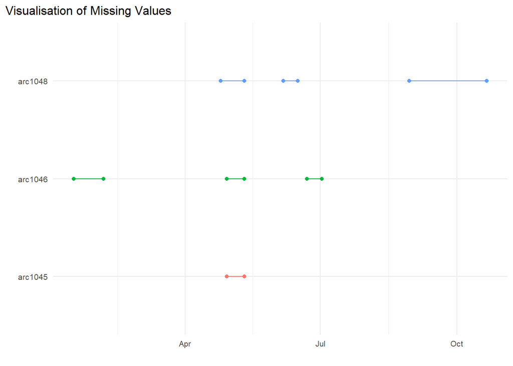

# Locations

[interactive chart not shown]

# Day

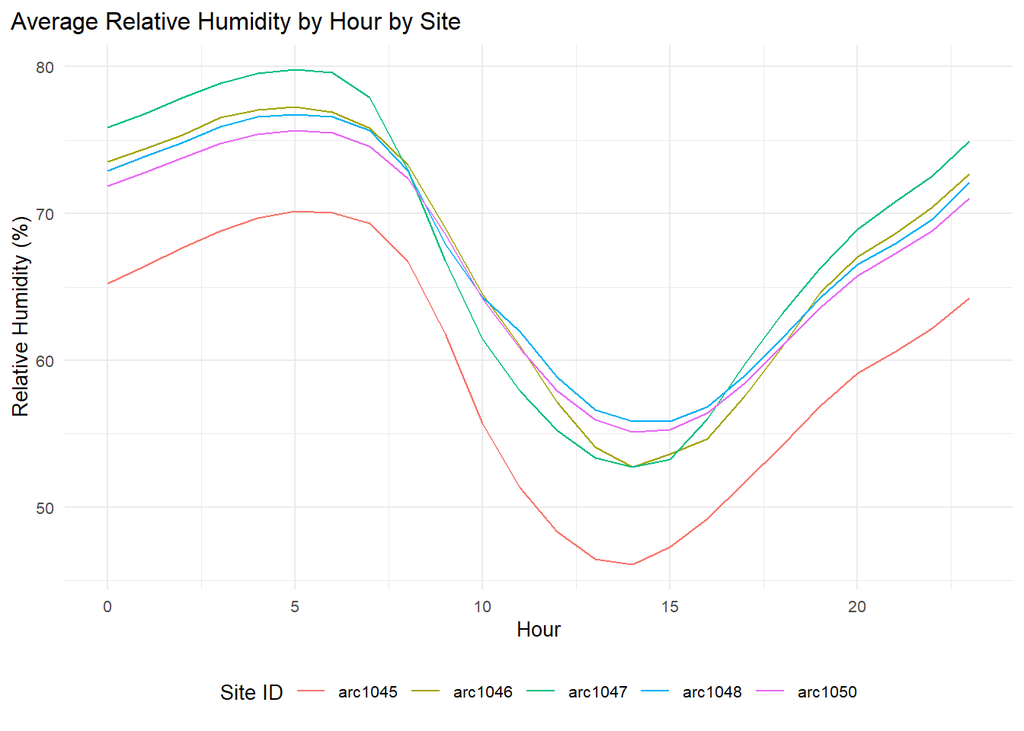

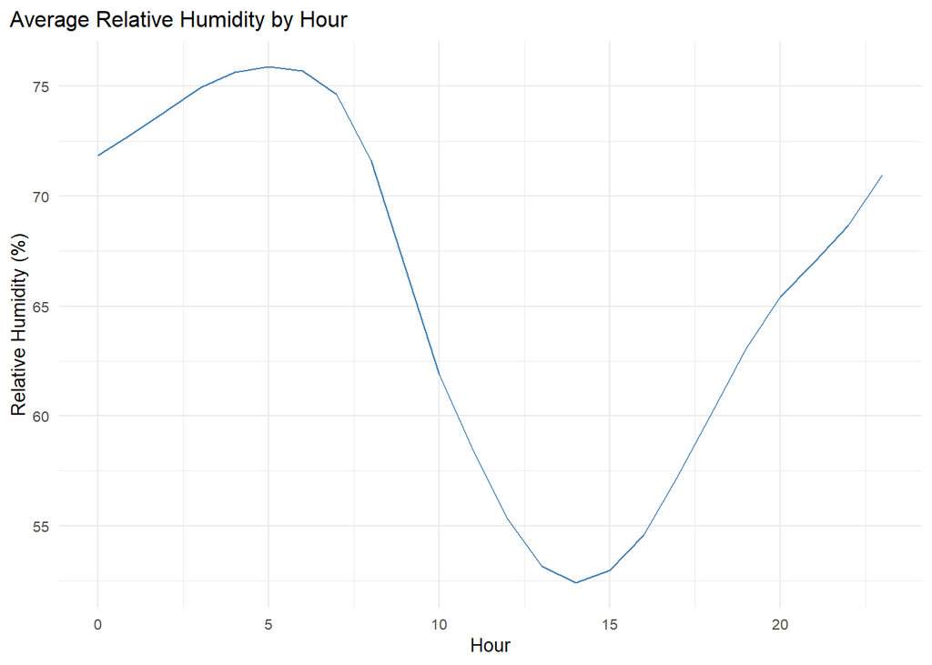

# Year

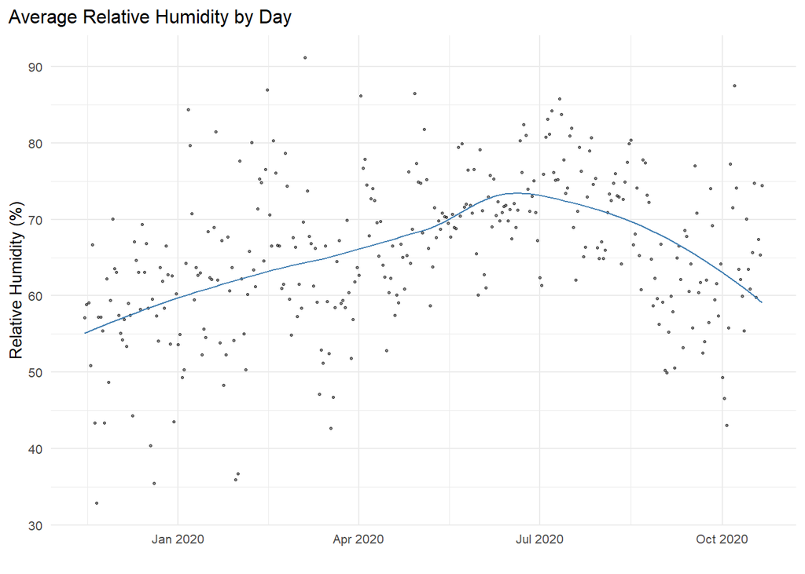

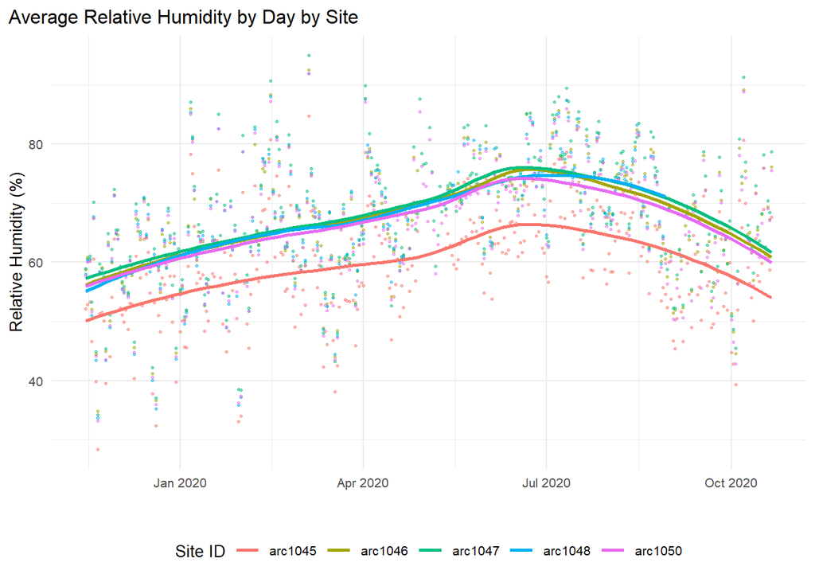

# Comparing Across Sensors

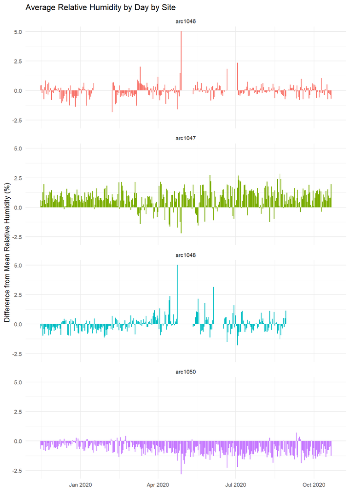

https://www.weathernationtv.com/news/dry-cold-vs-humid-cold/

# How does humidity effect US?

## When is it most uncomfortable to walk around the city (humidity below 30% or above 60%)?

Hot weather:

- Higher levels of humidity can make us feel even warmer
- The body is cooled through evaporation and higher levels of humidity can stifle this
- On warm days with high levels of humidity we can feel warmer and “sticky” as our sweat does not evaporate as efficiently
- Think about countries near the equator such as Singapore, or Northern Queensland.

Cold weather:

- By the same logic on colder days with higher humidity we should feel warmer
- However, it is the opposite: we feel colder on cold days with higher humidity
- High humidity impairs the insulation ability of clothing
- moisture in fibers and wicking effect of clothing can accelerate the heat loss through clothing
- Humidity creates a thin layer of moisture on fibers on the fibers and result in greater transfer of heat through clothing
- Think about rain on a cold day

#### It would be most uncomfortable to walk around the city on days with high humidity